Suppose a classification problem with $N$ patterns and $M$ classes, where the patterns are labeled with the variable $i=1,\ldots,N$ and the classes with $l=1,...,M$.

# **Representaciones**

**Vector representation**: As a vector of length $n$ where each element $i$ contains the label class $l$ to which it belongs. $$ y =[y_1, \ y_2, \ \ldots, \ y_N ], \qquad \text{where} \ \ y_i = l \ | \ x_i \in C_l $$

**Matrix representation** As a binary matrix of $M \times N$, where each cell $i,l$ is equal to 1 if $x_i \in C_l$, and 0 otherwise. $$ y = [ y_{l, i} ], \qquad y_{l,i} = \begin{cases} 1 & \text{if} \quad x_i\in C_l\\ 0 & \text{if} \quad x_i \not\in C_l \end{cases}, \qquad l=1,\ldots, M, \ i=1,\ldots, N$$

**Set of sets representation**: As a set of sets, a set of classes consisting of the indices of the patterns within the class: $$y = \left\{\begin{matrix} y_1 = \{i \ \mid \ x_i\in C_1, \ i=1,\ldots, N\}\\ y_2 = \{i \ \mid\ x_i\in C_2, \ i=1,\ldots, N\}\\ \vdots\\ y_M = \{i \ \mid\ x_i\in C_M, \ i=1,\ldots, N\}\\ \end{matrix}\right\}$$

## **Ejemplo**

$$Y = (1, 2, 2, 3, 3, 3, 4, 4, 4, 4)$$

$$ Y = \begin{bmatrix} 1 & 0 & 0 & 0 \\ 0 & 1 & 0 & 0 \\ 0 & 1 & 0 & 0 \\ 0 & 0 & 1 & 0 \\ 0 & 0 & 1 & 0 \\ 0 & 0 & 1 & 0 \\ 0 & 0 & 0 & 1 \\ 0 & 0 & 0 & 1 \\ 0 & 0 & 0 & 1 \\ 0 & 0 & 0 & 1 \end{bmatrix} $$

$$ Y = \left\{ \{1\}, \{2, 3\}, \{4, 5, 6\}, \{7, 8, 9, 10\} \right\} $$

$$\hat{Y} = (1, 1, 1, 1, 2, 2, 2, 3, 3, 4)$$

$$ \hat{Y} = \left\{ \{1, 2, 3, 4\}, \{5, 6, 7\}, \{8, 9\}, \{10\} \right\} $$\begin{align*} \hat{Y}_1 &= \{1, 2, 3, 4\} \\ \hat{Y}_2 &= \{5, 6, 7\} \\ \hat{Y}_3 &= \{8, 9\} \\ \hat{Y}_4 &= \{10\} \end{align*}

# **Matriz de Confusion**

Precisión

|  | Predicted | $\hat{y_1}$ | ... | $\hat{y_m}$ | Total |
| --- | --- | --- | --- | --- | --- |
| True |  |  |  |  |  |
| $Y_1$ |  |  |  |  | $s_1$ |
| ... |  |  |  |  |  |
| $Y_m$ |  |  |  |  | $s_m$ |
| Total |  | $p_1$ | ... | $p_m$ |  |

$$ s_i = \sum_{j=1}^m | Y = j, \hat{Y} = i |, \quad i \in \{1, 2, \dots, m\}\\ $$$$ \text{$s_i$ es el número de patrones que Sí son de la clase $i$, es la suma de las filas} $$

$$ p_i = \sum_{j=1}^m | Y = i, \hat{Y} = j |, \quad i \in \{1, 2, \dots, m\} \\ $$$$ \text{$p_i$ es el número de patrones que Predecimos en la clase $i$, es la suma de las columnas } $$

$$ M_c = \begin{bmatrix} |Y = 1, \hat{Y} = 1| & & |Y = 1, \hat{Y} = 2| & & \dots & & |Y = 1, \hat{Y} = m| \\ |Y = 2, \hat{Y} = 1| & & |Y = 2, \hat{Y} = 2| & & \dots & & |Y = 2, \hat{Y} = m| \\ |Y = 3, \hat{Y} = 1| & & |Y = 3, \hat{Y} = 2| & & \dots & & |Y = 3, \hat{Y} = m| \\ \vdots & & \vdots & & \ddots& & \vdots \\ |Y = m, \hat{Y} = 1| & & |Y = m, \hat{Y} = 2| & & \dots & & |Y = m, \hat{Y} = m| \\ \end{bmatrix} $$

$$ M_c = \begin{bmatrix} \text{Que sean 1 y los clasifiquemos como 1} & \text{que sean 1 y lo clasifiquemos como 2} & \dots \\ \text{Que sean 2 y los clasifiquemos como 1} & \text{que sean 2 y lo clasifiquemos como 2} & \dots \\ \text{Que sean 3 y los clasifiquemos como 1} & \text{que sean 3 y lo clasifiquemos como 2} & \dots \\ \vdots & \vdots & \ddots \end{bmatrix} $$

$$Y = (1, 2, 2, 3, 3, 3, 4, 4, 4, 4)$$$$\hat{Y} = (1, 1, 1, 1, 2, 2, 2, 3, 3, 4)$$

$$ M_c = \begin{bmatrix} 1 & 0 & 0 & 0 \\ 2 & 0 & 0 & 0 \\ 1 & 2 & 0 & 0 \\ 0 & 1 & 2 & 1 \end{bmatrix} $$

## **Metricas**

$$ M_{cT} = \begin{bmatrix} |Y = 1, \hat{Y} = 1| & & |Y = 1, \hat{Y} = 2| & & \dots & & |Y = 1, \hat{Y} = m| & | & s_1 \\ |Y = 2, \hat{Y} = 1| & & |Y = 2, \hat{Y} = 2| & & \dots & & |Y = 2, \hat{Y} = m| & | & s_2 \\ |Y = 3, \hat{Y} = 1| & & |Y = 3, \hat{Y} = 2| & & \dots & & |Y = 3, \hat{Y} = m| & | & s_3 \\ \vdots & & \vdots & & \ddots& & \vdots \\ |Y = m, \hat{Y} = 1| & & |Y = m, \hat{Y} = 2| & & \dots & & |Y = m, \hat{Y} = m| & | & s_m \\ \hline p_1 & & p_2 & & \dots & & p_m & | & N & \\ \end{bmatrix} $$

$$ M_{cT} = \begin{bmatrix} A(1, 1) & \dots & \dots & | \text{sí son de } C_1 \\ \dots & A(2, 2) & \dots & | \text{sí son de } C_2 \\ \vdots & \vdots & \vdots & \vdots & \\ \dots & \dots & A(M, M) & | \text{sí son de } C_M \\ \hline \text{predijimos } C_1 & \text{predijimos } C_2 & \dots \text{ predijimos } C_M & | \text{ Total} \end{bmatrix} $$

$$ \text{Accuracy} = \frac{\sum_{i=1}^m \left| Y = i, \hat{Y} = i \right|}{N} $$

$$ \text{Balanced Accuracy} = \frac{1}{M} \sum_{i=1}^{M} \frac{|Y = i, \hat{Y} = i|}{s_i} $$

$$ \begin{aligned} \text{Precision}_i &= \frac{|Y = i, \hat{Y} = i|}{p_i} \\ \text{Sensibility}_i &= \frac{|Y = i, \hat{Y} = i|}{s_i} \\ \text{F1}_i &= 2 \frac{P_i S_i}{P_i + S_i} \\ F\beta_i &= (1+\beta^2) \frac{P_i S_i}{\beta^2 P_i + S_i} \end{aligned} $$

Sensitibity is also Recall

$$ \begin{aligned} \text{Macro-Precision} &= \frac{1}{m} \sum_{i=1}^m \text{Precision}_i \\ \text{Macro-Recall} &= \frac{1}{m} \sum_{i=1}^m \text{Recall}_i \\ \text{Macro-F1} &= \frac{1}{m} \sum_{i=1}^m \text{F1}_i \\ \end{aligned} $$

$$ \begin{aligned} \text{Micro-Precision} &= \frac{\sum_{i=1}^m \text{True Positives}_i}{\sum_{i=1}^m \left(\text{True Positives}_i + \text{False Positives}_i\right)} \\ \text{Micro-Recall} &= \frac{\sum_{i=1}^m \text{True Positives}_i}{\sum_{i=1}^m \left(\text{True Positives}_i + \text{False Negatives}_i\right)} \\ \text{Micro-F1} &= 2 \cdot \frac{\text{Micro-Precision} \cdot \text{Micro-Recall}}{\text{Micro-Precision} + \text{Micro-Recall}} \end{aligned} $$

Matriz de Confusión con Totales

$$ M_{cT} = \begin{bmatrix} 1 & 0 & 0 & 0 & | & 1 \\ 2 & 0 & 0 & 0 & | & 2 \\ 1 & 2 & 0 & 0 & | & 3 \\ 0 & 1 & 2 & 1 & | & 4 \\ \hline 4 & 3 & 2 & 1 & | & 10 \end{bmatrix} $$

$$ \begin{align*} \text{Accuracy} &= \frac{1+0+0+1}{10} = 0.2 \\ \text{Balanced Accuracy} &= \frac{1}{4} \left( \frac{1}{1} + \frac{0}{2} + \frac{0}{3} + \frac{1}{4} \right) = 0.3125 \\ \text{Precisión}_1 &= \frac{1}{4} \\ \text{Sensibilidad}_1 &= 1 \\ \text{Precisión}_2 &= \frac{0}{3} \\ \text{Sensibilidad}_2 &= \frac{0}{2} \\ \text{Precisión}_3 &= \frac{0}{2} \\ \text{Sensibilidad}_3 &= \frac{0}{3} \\ \text{Precisión}_4 &= 1 \\ \text{Sensibilidad}_4 &= \frac{1}{4} \end{align*} $$

### **Errores**

> The **error probability of the false positive**, known as a **type I error**, is denoted by $\alpha$ (in which case the probability of the true positive is $1-\alpha$).

> The **error probability of a false negative**, known as a **type II error**, is denoted by $\beta$ (and the probability of a true negative is $1-\beta$).

**Confusion Matrix for the two-class problem.**

| True Class | Predicted Class |  | Total |  |
| --- | --- | --- | --- | --- |
|  | Positive | Negative |  |  |
| **Positive** | tp : true positive | fn : false negative |  | p |
| **Negative** | fp : false positive | tn : true negative | n |  |
| **Total** | p' | n' | N |  |

**Main performance measures**

> **Total Error**

$$e = \frac{fp+fn}{N}=\alpha + \beta$$

> **Accuracy** (*exactitud*), measures the proportion of correct predictions in relation to the total number of elements.

$$\frac{tp+tn}{N} = 1- e$$

> **False alarm rate** (**false positive fraction**) $fp$-rate is the proportion of impostors we wrongly accept.

$$\frac{fp}{n}=\alpha$$

> **True positive rate**, **recall** or **sensitivity** $tp$-rate, measures what proportion of valid users (positive pattern) we authenticate. Intuitively, it is the ability of the classifier to find all the positive samples.

$$ \frac{tp}{p}=1-\alpha$$

> **Precision** measures the proportion of records classified as positive that actually are. Intuitively, precision is the ability to the classifier not to label as positive a sample that is negative.

$$\frac{tp}{p'}$$

> **Specificity** is how well we detect the negatives.

$$\frac{tn}{n} = 1 - fp\text{-rate}$$

$$Y = (1, 1, 1, 2, 2, 1, 1, 2, 3, 3)$$$$\hat{Y} = (1, 1, 1, 2, 2, 2, 2, 3, 3, 3)$$

Errores

$$R_1 = \frac{0}{3} + \frac{0}{2} = 0 $$$$R_2 = \frac{2}{5} + \frac{0}{2} = \frac{2}{5} $$$$R_3 = \frac{0}{5} + \frac{2}{3} = \frac{2}{3} $$

# **Comparación de Modelos con teoría de la información**

## **Jaccard similarity coefficient**

Measures the similarity of label sets $y_l$ and $\hat{y}_l$ (in set of sets representation).

The coefficient for each label $l$ is $$J_l = J(y_l, \hat{y}_l) = \frac{|y_l\cap \hat{y}_l|}{|y_l\cup \hat{y}_l|}$$

Example $$ y = (1, 2, 2, 3, 3, 3, 4, 4, 4, 4) $$ $$ \hat{y} = (1, 1, 1, 1, 2, 2, 2, 3, 3, 4)$$

$$ J_1 = J(y_1, \hat{y}_1) = \frac{1}{4}$$

**Jaccard coefficient-Macro**: $$\frac{1}{M} \sum_{l=1}^M J(y_l, \hat{y}_l)$$

**Jaccard coefficient-Weighted**: $$\frac{1}{N}\sum_{l=1}^M |y_l| J(y_l, \hat{y}_l)$$

## **Hamming loss function**

In information theory, the **Hamming distance** is defined as the number of positions at which two strings or vectors of the same length differ. Essentially, it quantifies the minimum number of substitutions needed to transform one string into the other.

$$ L_{hamming}(y, \hat{y}) = \frac{1}{N} \sum_{i=1}^N 1(y_i \neq \hat{y}_i)$$

Example $$ y = (1, 2, 2, 3, 3, 3, 4, 4, 4, 4) $$ $$ \hat{y} = (1, 1, 1, 1, 2, 2, 2, 3, 3, 4)$$

### **Joint Distribution**

The joint distribution of two random variables 𝑋 X and 𝑌 Y describes how they occur together.

$$p(l, l') = P(l \cap l') = \frac{|y_l \cap y_{l'}|}{N}$$

$$ p(Y, \hat{Y} ) = \frac{1}{N} M_c $$

$$ p(Y, \hat{Y} ) = \begin{bmatrix} .1 & 0 & 0 & 0 \\ .2 & 0 & 0 & 0 \\ .1 & .2 & 0 & 0 \\ 0 & .1 & .2 & .1 \end{bmatrix} $$

$$ p(Y, \hat{Y} ) = \begin{bmatrix} .1 & 0 & 0 & 0 & | & .1 \\ .2 & 0 & 0 & 0 & | & .2 \\ .1 & .2 & 0 & 0 & | & .3 \\ 0 & .1 & .2 & .1 & | & .4 \\ \hline .4 & .3 & .2 & .1 & | & 1 \end{bmatrix} $$

### **Entropy**

Entropy is a measure of uncertainty or disorder in a dataset. It tells us how unpredictable or mixed the data is.

$$ \Eta (X) = \sum_{x \in X} p(x) \log_2 \frac{1}{p(x)}= -\sum_{x \in X} p(x) \log_2 p(x)$$

Donde $p(x) := \mathbb{P}[X = x]$

$$ \Eta (X) = \sum_{i=1}^m \mathbb{P}(X = i) \log_2 \frac{1}{\mathbb{P}(X = i)}= -\sum_{i=1}^m \mathbb{P}(X = i) \log_2 \mathbb{P}(X = i)$$

$$Y = (1, 2, 2, 3, 3, 3, 4, 4, 4, 4)$$$$ \Eta (Y) =\frac{1}{10}\log_2\frac{10}{1} +\frac{2}{10}\log_2\frac{10}{2} +\frac{3}{10}\log_2\frac{10}{3} +\frac{4}{10}\log_2\frac{10}{4} = 1.85 \ \text{bits}$$

### **Mutual Information**

**Mutual information** measures how much knowing one variable reduces uncertainty about another. It’s like asking, **"How much does knowing $X$ help me predict $Y$?"**

**Example:**

- If $X$ = “amount of study” and $Y$ = “exam score,” a high **mutual information** means studying strongly affects the score.
- If $X$ = “eye color” and $Y$ = “exam score,” mutual information is close to **zero** (they are unrelated).

**Use:**

- **Feature selection** (choosing the most relevant variables)
- **Clustering** (finding dependent structures in data)
- **Deep learning** (regularization techniques using MI)

$$I(X, Y) = \sum_{x \in \mathcal{X}, y \in \mathcal{y} }p(x,y) \log_2 \frac{p(x,y)}{p(x) p(y)}$$

where $p(x, y) = p_{X,Y}(x,y) := \mathbb{P}[X = x, Y = y]$ and $p(y) = p_{Y}(y) = \mathbb{P}[Y = y]$.

$$ p(Y, \hat{Y}) = \begin{bmatrix} .1 & 0 & 0 & 0 & | & .1 \\ .2 & 0 & 0 & 0 & | & .2 \\ .1 & .2 & 0 & 0 & | & .3 \\ 0 & .1 & .2 & .1 & | & .4 \\ \hline .4 & .3 & .2 & .1 & | & 1 \end{bmatrix} $$

$$I(X, Y) = \mathrm{H} (Y) - \mathrm{H} (Y|X) = \mathrm{H} (X) - \mathrm{H} (X|Y)$$

Cuando una columna es siempre igual, la informacion mutua es 0.  
Cuando cambian igual (o completamente diferente) es algo cerca de 0.5

### **Bayes' Theorem**

Bayes' theorem updates our belief about an event given new evidence.

$$ P(A|B) = \frac{P(A \cap B)}{P(B)} = \frac{P(A,B)}{P(B)} = \frac{P(B|A) P(A)}{P(B)} $$

### **Conditional Entropy**

This measures the **remaining uncertainty** in $Y$ after knowing $X$.

**Example:**

- If $X$ = "weather" and $Y$ = "umbrella usage,"
  - If weather perfectly determines umbrella use, $H(Y | X) = 0$ (no uncertainty left).
  - If people randomly choose to carry umbrellas, $H(Y | X)$ is **high** (still uncertain).

**Use:**

- **Decision trees** (choosing splits based on entropy reduction)
- **Information theory** (data compression, signal processing)

One may also define the conditional entropy of two variables $X$ and $Y$ taking values from sets $\mathcal{X}$ and $\mathcal{Y}$ respectively, as:

$$ \mathrm{H}(X|Y) = -\sum_{x,y \in \mathcal{X} \times \mathcal{Y}} p(x,y) \log \frac{p(x,y)}{p(y)}, $$

$$\mathrm{H}(X|Y) = \mathrm{H}(X) -I(X,Y)$$

$$ p(Y, \hat{Y}) = \begin{bmatrix} .1 & 0 & 0 & 0 & | & .1 \\ .2 & 0 & 0 & 0 & | & .2 \\ .1 & .2 & 0 & 0 & | & .3 \\ 0 & .1 & .2 & .1 & | & .4 \\ \hline .4 & .3 & .2 & .1 & | & 1 \end{bmatrix} $$

$$ - \mathrm{H}(Y|\hat{Y}) = 0.1 \log_2 \frac{0.1}{0.4} + 0.2 \log_2 \frac{0.2}{0.4} + 0.1 \log_2 \frac{0.1}{0.4} + 0.2 \log_2 \frac{0.2}{0.3} + 0.1 \log_2 \frac{0.1}{0.3} + 0.2 \log_2 \frac{0.2}{0.2} + 0.1 \log_2 \frac{0.1}{0.1} $$

### **Variaton of Information**

This measures **how different two distributions are**. It’s based on **mutual information** but tells us what information is **lost or gained** when switching between them.  
**(Total uncertainty left when switching between $X$ and $Y$)**

**Example (Clustering Differences):**

- Suppose you cluster customers based on spending habits.
- If two algorithms give **very different** clusters, VI is **high**.
- If both algorithms give **similar** clusters, VI is **low**.

**Use in Data Science:**

- **Comparing clustering algorithms**
- **Information loss in feature selection**

$$VI(Y, \hat{Y}) = \Eta(Y) + \Eta(\hat{Y}) -2I(Y, \hat{Y})$$

This is the sum of two positive terms $$VI(Y, \hat{Y}) = [\Eta(Y) -I(Y,\hat{Y})] + [\Eta(\hat{Y})-I(Y,\hat{Y})] = \Eta(Y|\hat{Y}) + \Eta(\hat{Y}|Y)$$

### **Metric**

**(Distance Measures)** A **metric** quantifies how different or similar two points or distributions are.

**Common Metrics:**

- **Euclidean distance** (for continuous data)
- **Manhattan distance** (for grid-based paths)
- **Hamming distance** (for binary data)
- **Kullback-Leibler (KL) divergence** (for probability distributions)

**Example:**

- In a **recommender system**, the metric determines how close two users’ preferences are.

**Use in Data Science:**

- **Clustering (k-means, hierarchical clustering)**
- **Nearest neighbor algorithms (k-NN, content-based filtering)**
- **Anomaly detection (distance from normal behavior)**

# **ROC Curve**

The **ROC curve** evaluates a classifier’s performance across different thresholds.

🔹 **Axes:**

- **X-axis:** False Positive Rate (FPR)
- **Y-axis:** True Positive Rate (TPR)

🔹 **Key Metrics:**

- **AUC (Area Under the Curve)** → Higher AUC = Better classifier
- **Closer to top-left = Better model**

🔹 **Example:**

- A **perfect classifier** has an AUC of **1.0**.
- A **random classifier** (coin flip) has an AUC of **0.5**.

**Use in Data Science:**

# **Receiver Operating Characteristic curve (ROC curve)**

Given a two-class classification problem ($\omega_1$ and $\omega_2$), we denote the **Type I Error** (**error probability of the false positive**) with $\alpha$, and let $\beta$ be the **Type II Error** (**error probability of a false negative**).

As we saw previously,

> The **total error** is equal to $\alpha+\beta$.

> The **sensitivity** or **recall** (**True Positive Fraction TPF**) is

$$ \frac{TP}{p}=1-\alpha$$

> The **FP-rate** (**False Positive Fraction FPF**) is

$$ \frac{FP}{n} = \alpha = 1- \text{specifity}$$

where $TP$, $FP$, $FN$ and $TN$ are the True positive, false negative, false negative and true false, respectively. The number of true positive is denoted by $p$ and the number of true negative with $n$.

When we have a parametric classifier, by moving a parameter, we can obtain different values of $\alpha$ and $\beta$.

When the threshold is at the intersection of the two curves, the total error $(\alpha+\beta)$ is a minimum: choosing the threshold (i.e., decision point) at the intersection minimizes the (total) probability of error and is the optimal decision rule.

> On either side of the intersection, we can reduce $\alpha$ by increasing the threshold or we can reduce $\beta$ by reducing the threshold, but the total error will be larger than at the intersection point.

TPR = Sensibility  
FPR = 1 - Specificitfy

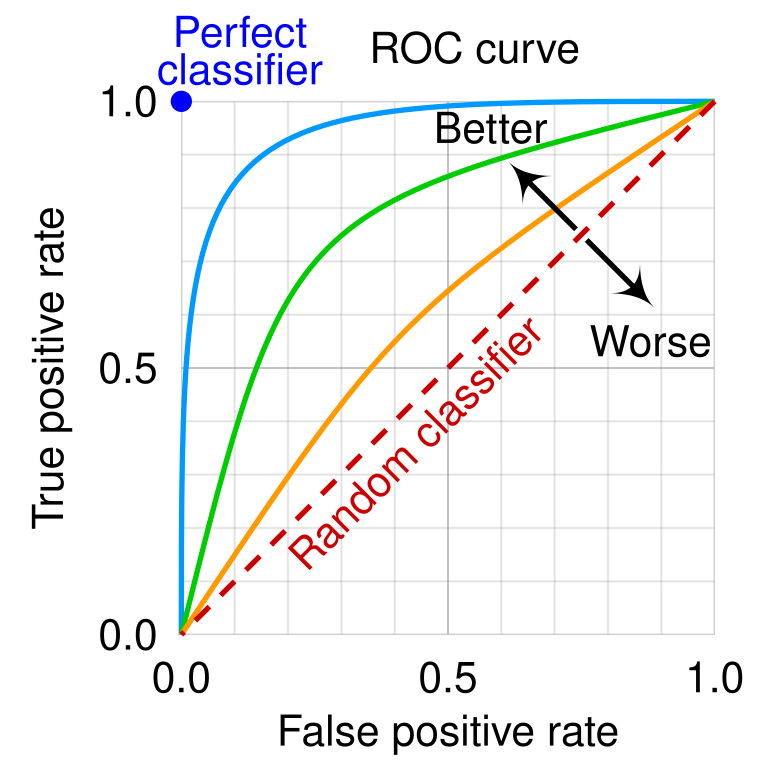

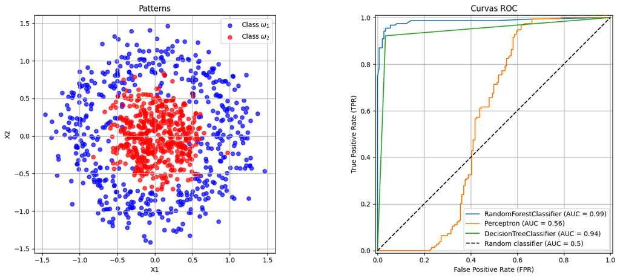

## **The AUC score**

**The ROC curve** allows a visual analysis; if we want to reduce the curve to a single number we can do this by calculating the **Area Under the Curve (AUC)**.

> A classifier ideally has an AUC of 1 and AUC values of different classifiers can be compared to give us a general performance averaged over different loss conditions.

> > If the two distributions overlap a lot, the ROC line drops close to the diagonal and the area below it (the **AUC**) drops towards 0.5: A value of exactly 0.5 indicates that there is complete overlap, and a classifier using this feature will be no better than random choice at discriminating the classes.

> > If the two distributions are well separated, the ROC line rises and the AUC approaches 1.